# Practice for Exam, Answers

Misja Mikkers, Gertjan Verhoeven & Has van Vlokhoven

# Packages needed

```r
library(tidyverse)
library(readxl)
library(writexl)
library(palmerpenguins)
library(gapminder)
```

# Introduction

In this pdf we will show you examples of exam questions.

# Assignment 0

Pull the repository https://github.com/misjamikkers/Rprogramming21_student to find the data needed for the exam, the exam and the answers.

# Question 1

In the Sourcedata folder (and on Canvas) you will find the excelfile with the name dataQ1.xlsx

Your task is to

1. read this data into a R notebook
2. keep the rows of Group1
3. make a scatterplot with Variable_1 on the x-axis and Variable_2 on the y_axis

Which figure do you recognize in the graph?

1. Dinosaur
2. Heart
3. the letter “L”
4. the number “1”

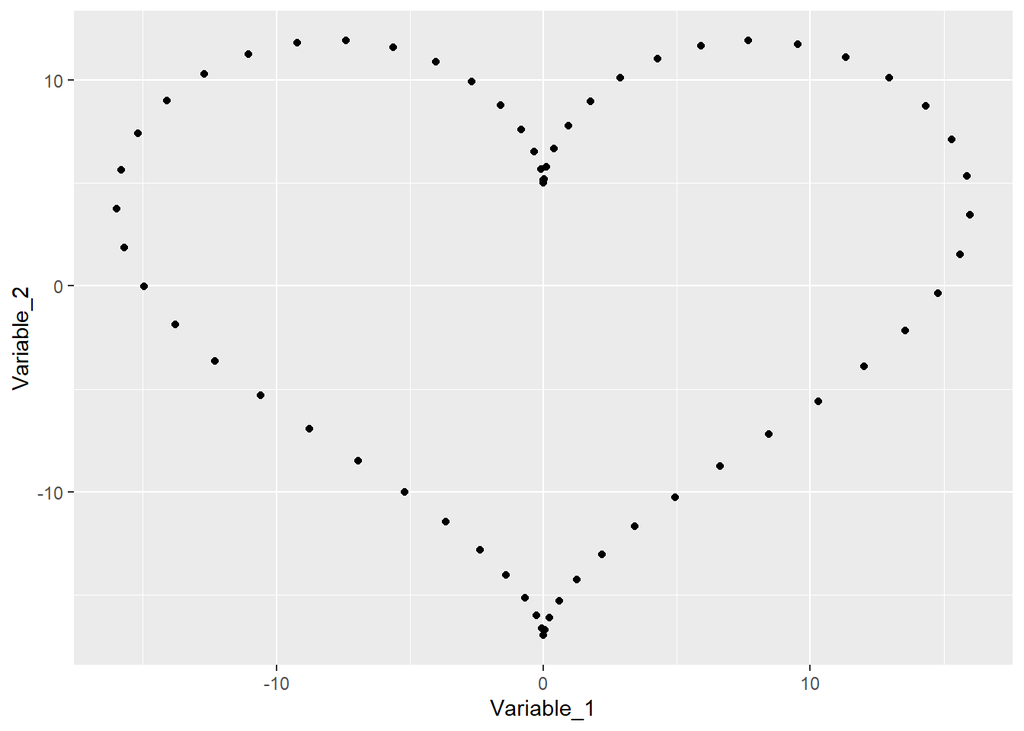

```r
Q1_xlsx <- read_xlsx("../Sourcedata/dataQ1.xlsx") %>%
  filter(Group == "Group1")

ggplot(Q1_xlsx, aes(x = Variable_1, y = Variable_2)) +
  geom_point()
```

Answer B: Heart

# Question 2

Your task is to

- use the penguins data from the palmerpenguins package
- keep the rows with year 2009
- create a boxplot with on the x-axis Species per sex and on the y-axis body_mass_g.

Which species per sex has the highest median body mass?

1. females of the Adelie species
2. males of the Adelie species
3. females of the Chinstrap species
4. males of the Chinstrap species
5. females of the Gentoo species
6. males of the Gentoo species
7. the NA group

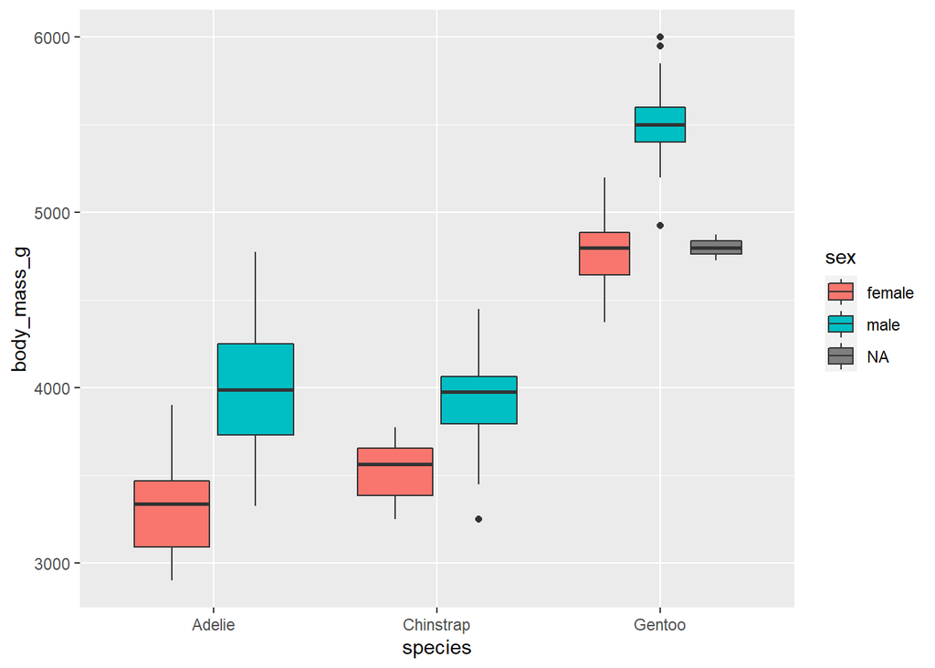

```r
penguins %>%
  filter(year == 2009) %>%
  ggplot(aes(x = species, y = body_mass_g, fill = sex)) +
    geom_boxplot()
```

F: Gentoo males

# Question 3

Your task is

- use the data of the gapminder package
- keep the rows of year 2007
- calculate the medium life expectancy (lifeExp) per continent

What is the median life expectancy of Oceania? Round your answer to the nearest integer.

```r
gapminder %>%
  filter(year == 2007) %>%
  group_by(continent) %>%
  summarise(Median_LE = median(lifeExp))
```

|  | continent | Median_LE |
| --- | --- | --- |
| 1 | Africa | 52.9265 |
| 2 | Americas | 72.8990 |
| 3 | Asia | 72.3960 |
| 4 | Europe | 78.6085 |
| 5 | Oceania | 80.7195 |

# Question 4a

Your task is to

- Copy the code below (NOTE: include the set.seed!!!) into a notebook
- Use left_join to merge m1 and m2 (in that order!) in to a dataframe with the name “m3”

```r
set.seed(123)

m1 <- tibble(id = sample(x= 1:100, size = 70, replace = TRUE)) %>%
  mutate(x = rnorm(n = length(id), mean = 0, sd = 1))

m2 <- tibble(id = sample(x= 1:100, size = 80, replace = TRUE)) %>%
  mutate(y = rnorm(n = length(id), mean = 10, sd = 5 ))

m3 <- left_join(m1, m2, by = "id")
```

How many observations (rows) does m3 have?

97 observations

## Question 4b

Your task is to use m3 from question 4a to

- create a long dataframe m4 with a new colum “Var” that indicates whether the row concerned shows a value of “x” or “y” and the values in column “Val”.

So your dataframe should look like:

| id | Var | Val |
| --- | --- | --- |
| 31 | x | -0.1639310 |
| 31 | y | 14.3968207 |
| … | … | …. |
| …. | … | …. |

- Then delete all NA’s.

```r
m4 <- m3 %>%
  pivot_longer(x:y, names_to = "Var", values_to = "Val") %>%
  na.omit()
```

How many observations (rows) does m4 have?

166 observations

# Question 5

What does this code do?

`knitr::opts_chunk$set(echo = FALSE)`

1. The code makes sure that this code chunk will not be executed
2. The code makes sure that all the code chunks after this command in the Rmd will not be executed
3. The code makes sure that this code chunk will not be shown in the output document (e.g. the pdf)
4. The code makes sure that all the code chunks after this chunk will not be shown in the output document (e.g. the pdf)

D

## Question 6

```r
set.seed(123)

tibble(x = rnorm(1000, mean = 0, sd = 1)) %>%
  mutate(y = (sin(x^2) + 33 * (x^4))) %>%
  summarise(mean_y = mean(y))
```

| mean_y |
| --- |
| 93.71417 |

mean of y is 93.71417.

# Question 7

Create a function that for the numbers x to x + 2 * $\pi$ calls the function `sin(x)` and adds the results.

The answer when you execute your function with the argument 3 should be 0.2044411

```r
fq7 <- function(x) {
  internal <- 0
  for (i in x:(x+2*pi)) {
    internal = internal + sin(i)
  }
  internal
}

fq7(3)
```

```
## [1] 0.2044411
```